# Grid-based pivot probabilities

Andy Eggers

13 August 2020

One approach to computing pivot probabilities, given a belief distribution for which we can compute densities, is grid-based numerical integration. Specifically, we

1. define a grid of points that satisfy the conditions of the pivot probabilities,
2. compute the density at each point,
3. sum up the densities and normalize using the volume surrounding each grid point.

This note is to explain the work I’ve done on this, including checks on whether it is working.

## Plurality

I don’t think I really need grid-based methods for plurality, because the analytical solution we have already is fast and accurate. But working through the issues might help determine what problems we face in the harder cases. It is also possible that the grid-based approach yields better answers because, unlike the analytical approach in Eggers & Vivyan, it doesn’t make the independence assumption about lower-finishing candidates.

For three candidates, the tie grid for $a$ and $b$ is the line where $a$ and $b$ receive the same vote share between 1/3 and 1/2; for four candidates it is the plane where $a$ and $b$ receive the same vote share between 1/4 and 1/2 and $c$ and $d$ receive lower vote shares.

We can define a grid for $k$ candidates in the method `plurality_tie_grid()` by specifying all combinations vote shares for $k-2$ candidates, then requiring that the $k-1$th candidate has the same share as the first, and then specifying the $k$th candidate to have 1 minus the sum of the other candidates’ shares. Then we prune such that

- the 1st has the highest vote share
- the $k$th candidate’s share is positive (actually, greater than the minimum of all other shares, i.e. the first increment in the grid).

Let’s show how this works. We will show:

- that the grid-based approach gets closer and closer to a large (slow) direct Monte Carlo draw as the grid gets finer and finer
- that the RMSE of the grid-based answer gets closer and closer to the Monte Carlo draw as the size of the Monte Carlo draw gets bigger (and we will compare this convergence to the convergence of the analytical solution).

Here is the simulation:

```r
source("R/grid_based_pivot_probs.R")
source("R/plurality_pivprobs.R")
library(tidyverse)
```

```r
# ultimately these will be part of the package

# we want to:
# draw an alpha_vec
# compute sim-based results (3?)
# get grid based results (3?)
# get analytical results

Ns <- c(10000, 100000, 1000000, 10000000)

set.seed(123)
J <- 100

v_mat <- gtools::rdirichlet(J, alpha = c(5, 4, 3, 2))
ss <- runif(J, min = 10, max = 50)

gb_store <- list()
a_store <- list()
sim_store <- list()

for(j in 1:J){

  cat(j, ": ", sep = "")
  v_vec <- as.numeric(v_mat[j,])
  s <- ss[j]
  alpha_vec <- rep(1, length(v_vec)) + v_vec*s

  # simulation-based answers
  cat(" s ")
  df <- tibble(N = Ns)
  df %>%
    mutate(sim_result = pmap(., plurality_pivot_probs_simulation_based, alpha = alpha_vec)) %>%
    unnest_longer(col = sim_result, values_to = "value", indices_to = "pp")  %>%
    mutate(j = j) -> sim_results

  sim_store[[j]] <- sim_results

  # grid-based results
  cat(" g ")
  df <- tibble(increment = (1:5)/100) %>%
    mutate(gb_result = pmap(., plurality_pivot_probs_grid_based, alpha_vec = alpha_vec, cand_names = letters[1:length(alpha_vec)])) %>%
    unnest_longer(col = gb_result, values_to = "value", indices_to = "pp")  %>%
    mutate(j = j) -> gb_results

  gb_store[[j]] <- gb_results

  # analytical results
  cat(" a.\n")
  alpha.vec <- alpha_vec
  names(alpha.vec) <- letters[1:length(alpha.vec)]
  dfa <- tibble(n = 1) %>%
    mutate(a_result = pmap(., pivotal.probabilities.analytical, alpha.vec = alpha.vec)) %>%
    unnest_longer(col = a_result, values_to = "value", indices_to = "pp")  %>%
    mutate(j = j) -> a_results

  a_store[[j]] <- a_results

}
```

```
## 1:  s  g  a.
## 2:  s  g  a.
## 3:  s  g  a.
## 4:  s  g  a.
## 5:  s  g  a.
## 6:  s  g  a.
## 7:  s  g  a.
## 8:  s  g  a.
## 9:  s  g  a.
## 10:  s  g  a.
## 11:  s  g  a.
## 12:  s  g  a.
## 13:  s  g  a.
## 14:  s  g  a.
## 15:  s  g  a.
```

[output cut: 85 more lines]

First we prep the data:

```r
big_sim <- bind_rows(sim_store) %>% filter(N == 10000000)

bind_rows(gb_store) %>%
  left_join(big_sim %>% select(-N), by = c("pp", "j"), suffix = c("_grid", "_sim")) -> for_rmses

for_rmses %>%
    group_by(increment, j) %>%
    summarize(rmse = sqrt(sum((value_grid - value_sim)^2)/n()),
              rmse_norm = sqrt(sum((value_grid/sum(value_grid) - value_sim/sum(value_sim))^2)/n())) -> the_rmses
```

Now we show that the grid-based approach tends to get closer to the result of a large, slow direct Monte Carlo simulation as the grid step-size gets smaller:

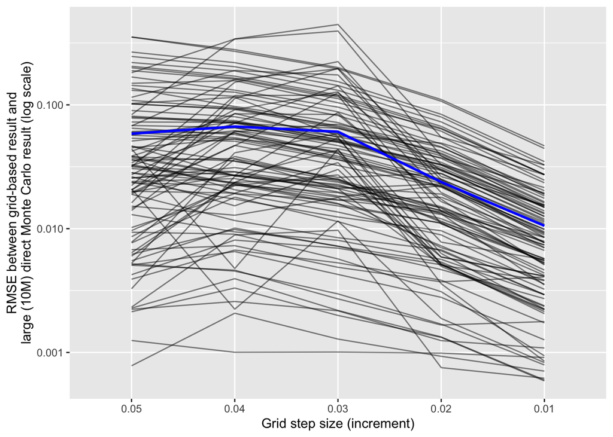

```r
# changed?
the_rmses %>%
  ggplot(aes(x = factor(increment, levels = c(.05, .04, .03, .02, .01)), y = rmse, group = j)) +
  geom_line(alpha = .5) +
  scale_y_log10() +
  geom_line(data = the_rmses %>% group_by(increment) %>% summarize(rmse = mean(rmse)), aes(x = factor(increment, levels = c(.05, .04, .03, .02, .01)), y = rmse), col = "blue", lwd = 1) +
  labs(x = "Grid step size (increment)", y = "RMSE between grid-based result and\nlarge (10M) direct Monte Carlo result (log scale)")
```

Another way of looking at the same data:

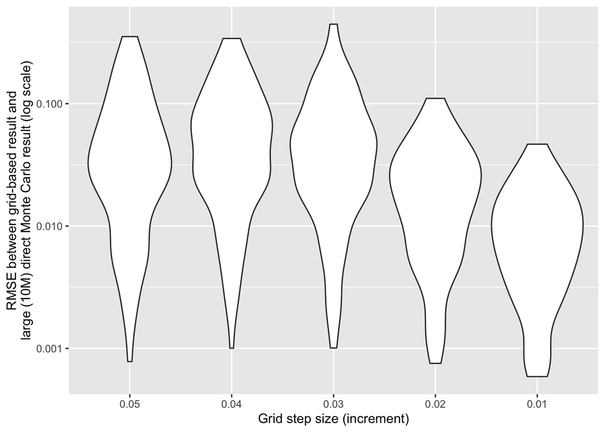

```r
# changed?
the_rmses %>%
  ggplot(aes(x = factor(increment, levels = c(.05, .04, .03, .02, .01)), y = rmse)) +
  geom_violin() +
  scale_y_log10() +
  labs(x = "Grid step size (increment)", y = "RMSE between grid-based result and\nlarge (10M) direct Monte Carlo result (log scale)")
```

```r
# changed?
the_rmses %>%
  select(-rmse_norm) %>%
  pivot_wider(id_cols = c(j), names_from = increment, values_from = rmse, names_prefix = "rmse_") -> rg_wide

rg_wide %>%
  filter(rmse_0.05/rmse_0.03 < .5) %>%
  pull(j) ->
  bad_js

rg_wide %>%
  filter(rmse_0.05/rmse_0.03 > 1.75) %>%
  pull(j) ->
  good_js

alpha_mat <- v_mat*ss + matrix(1, nrow = nrow(v_mat), ncol = ncol(v_mat))
alpha_mat[bad_js,]
```

```
##            [,1]      [,2]      [,3]     [,4]
##  [1,] 12.415371  6.680187  2.157619 1.167753
##  [2,] 20.131932 12.259911 10.891041 2.255994
##  [3,]  7.753302  7.180392  2.709969 1.310643
##  [4,] 20.147022 16.828660  8.468329 4.051380
##  [5,] 26.826446 10.738724 12.548868 3.434317
##  [6,] 10.329287  3.073410 14.041253 3.217943
##  [7,] 19.892428 20.627027  9.243995 4.191856
##  [8,] 12.604202  6.930230  7.212278 2.540456
##  [9,] 12.104550  6.377804  2.041541 1.393051
## [10,] 26.937576 16.967780  6.246851 1.703785
## [11,] 18.749937 11.915300 18.494854 3.010108
## [12,] 12.011047  4.185665  5.376154 1.469681
## [13,]  6.790107 24.821534 18.302022 1.647186
## [14,] 20.016034  4.132417 12.775896 2.071875
## [15,] 16.091473 16.268709  6.624820 4.098457
## [16,] 20.730636 23.383179  6.683275 2.464637
## [17,] 19.932757  8.140327  8.677210 1.847864
## [18,] 20.052830 19.034425 10.286476 3.538410
## [19,] 13.419076 13.552076  5.770899 3.905246
## [20,] 10.049056 11.001444 14.047357 3.827311
```

```r
alpha_mat[good_js,]
```

```
##            [,1]      [,2]      [,3]      [,4]
##  [1,]  3.932032  6.259984  1.469033  2.438103
##  [2,] 14.953760  9.227510 12.362804 12.705309
##  [3,] 13.971777  7.597008 12.668444  8.486443
##  [4,]  5.352403  4.676812  4.503029  2.057802
##  [5,]  5.745145  8.601517  1.926921  4.032928
##  [6,]  3.852571  8.261990  2.106199  2.938087
##  [7,] 17.128391 10.303079  9.909431  9.205833
##  [8,] 16.046418 13.305022 13.582476  3.153392
##  [9,]  3.835498  5.379747  4.596655  1.912792
## [10,]  8.556776 13.400583 12.050206 12.046247
## [11,]  7.215320  2.674014  3.472939  2.322848
## [12,]  7.382365 22.202847  7.518739 11.534732
## [13,]  4.589008  4.800815  4.110805  1.769665
## [14,] 10.161670  5.442023  1.893362  2.359887
## [15,]  7.042175  4.584082  2.490907  2.505265
## [16,] 24.137662 14.762074  7.052096  5.541263
```

I don’t see much pattern there. It’s a mystery.

Next we show that the grid-based approach with a small increment tends to get closer to the direct Monte Carlo result as the size of the Monte Carlo simulation gets bigger:

```r
# changed?
bind_rows(gb_store) %>%
  mutate(type = "grid") %>%
  filter(increment == .01) %>%
  select(-increment) %>%
  bind_rows(
    bind_rows(a_store) %>%
      mutate(type = "analytical") %>%
      select(-n)) %>%
  right_join(bind_rows(sim_store), by = c("pp", "j"), suffix = c("", "_sim")) -> for_rmses

for_rmses %>%
    group_by(type, j, N) %>%
    summarize(rmse = sqrt(sum((value - value_sim)^2)/n()),
              rmse_norm = sqrt(sum((value/sum(value) - value_sim/sum(value_sim))^2)/n())) -> the_rmses
```

```r
the_rmses %>% group_by(N, type) %>% summarize(rmse = mean(rmse)) -> means_by_N_and_type

means_by_N_and_type
```

```
## # A tibble: 8 x 3
## # Groups:   N [4]
##          N type         rmse
##      <dbl> <chr>       <dbl>
## 1    10000 analytical 0.0534
## 2    10000 grid       0.0523
## 3   100000 analytical 0.0206
## 4   100000 grid       0.0196
## 5  1000000 analytical 0.0130
## 6  1000000 grid       0.0125
## 7 10000000 analytical 0.0105
## 8 10000000 grid       0.0106
```

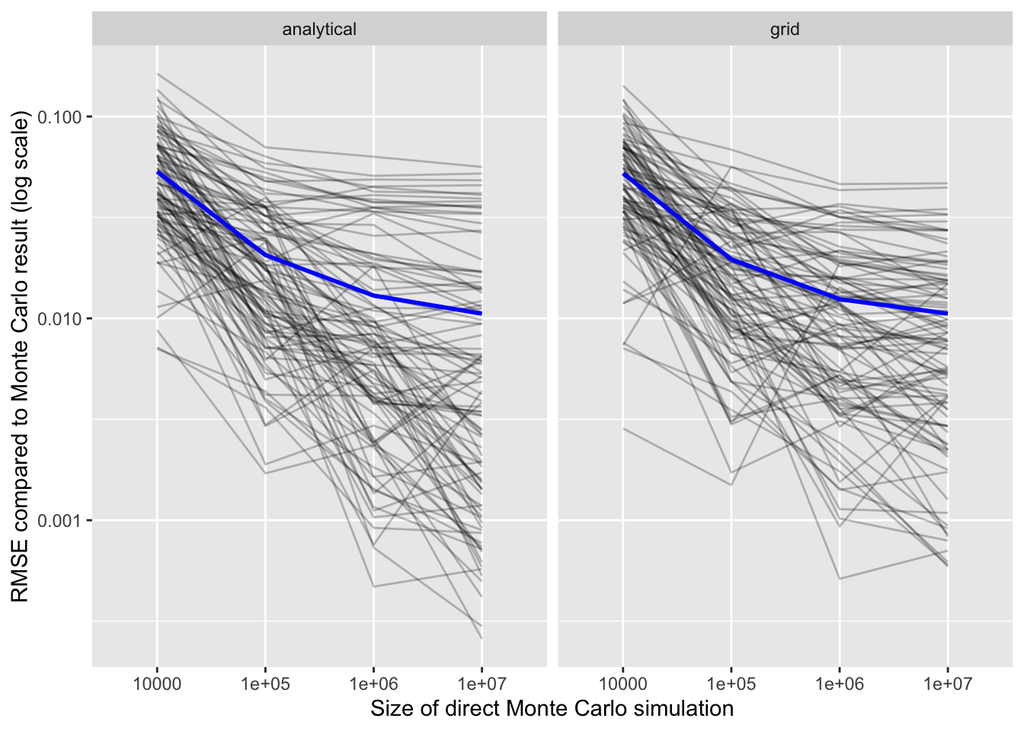

```r
# changed?
the_rmses %>%
  ggplot(aes(x = factor(N), y = rmse, group = j)) +
  geom_line(alpha = .25) +
  scale_y_log10() +
  geom_line(data = means_by_N_and_type, aes(x = factor(N), y = rmse, group = type), col = "blue", lwd = 1) +
  facet_wrap(. ~ type) +
  labs(x = "Size of direct Monte Carlo simulation", y = "RMSE compared to Monte Carlo result (log scale)")
```

The same thing on the linear scale:

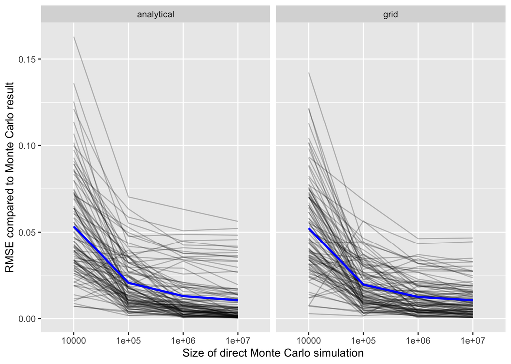

```r
# changed
the_rmses %>%
  ggplot(aes(x = factor(N), y = rmse, group = j)) +
  geom_line(alpha = .25) +
  geom_line(data = means_by_N_and_type, aes(x = factor(N), y = rmse, group = type), col = "blue", lwd = 1) +
  facet_wrap(. ~ type) +
  labs(x = "Size of direct Monte Carlo simulation", y = "RMSE compared to Monte Carlo result")
```

I thought something might be wrong with my approach to plotting means as they look identical, but in fact they are nearly identical:

```r
means_by_N_and_type %>% pivot_wider(names_from = type, values_from = rmse)
```

```
## # A tibble: 4 x 3
## # Groups:   N [4]
##          N analytical   grid
##      <dbl>      <dbl>  <dbl>
## 1    10000     0.0534 0.0523
## 2   100000     0.0206 0.0196
## 3  1000000     0.0130 0.0125
## 4 10000000     0.0105 0.0106
```

This suggests that, at least when we get to a grid increment of .01, the error might be due to remaining random variation in the Monte Carlo.

## Positional methods

I can continue this about positional methods (e.g. Borda count), where I have encountered more problems.